# Palantir

元URL: https://nbviewer.jupyter.org/github/dpeerlab/Palantir/blob/master/notebooks/Palantir_sample_notebook.ipynb

Palantirは、分化軌道に沿って細胞を整列させるアルゴリズムです。 Palantirは、低次元の表現型多様体 (phenotypic manifold)を介した一連のステップによって、幹細胞が最終分化細胞に分化する確率過程として分化をモデル化します。 Palantirは細胞状態の連続性と細胞運命決定の確率性を効果的に捉えることができます。

```python
# Script for multiple runs of wanderlust
%load_ext autoreload
%autoreload 2
```

```python
import palantir

# Plotting and miscellaneous imports
import os
import matplotlib
import matplotlib.pyplot as plt
import pandas as pd

%matplotlib inline
```

```
findfont: Font family ['Raleway'] not found. Falling back to DejaVu Sans.
findfont: Font family ['Lato'] not found. Falling back to DejaVu Sans.
```

以下では元論文で使用したデータ（ヒト骨髄CD34+細胞）のサブセットをデモデータとして用います。 データは、前駆体ヘマトポエイト系幹細胞と赤血球および骨髄系の細胞 (progenitor Hematopoeitic stem cells and cells of the erythroid and myeloid lineages)で構成されています。

```python
# Load sample data
#git clone https://github.com/dpeerlab/Palantir.git
counts = palantir.io.from_csv('Palantir/data/marrow_sample_scseq_counts.csv.gz')

# For alternative file formats
## palantir.io.from_mtx
## palantir.io.from_10x
## palantir.io.from_10x_HDF5
```

## Data clean up

分子数の少ない細胞や検出率の低い遺伝子を除去する

[output not shown]

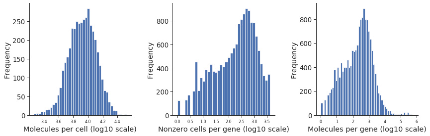

```python
# 分子数と遺伝子の検出率を視覚化
fig, ax = palantir.plot.plot_molecules_per_cell_and_gene(counts)
```

The dataset provided is already prefiltered. For other datasets, cells and genes can be filtered using

```python
filtered_counts = palantir.preprocess.filter_counts_data(counts, cell_min_molecules=1000, genes_min_cells=10)
```

## Normalization

- Palantirは、各細胞のカウントを総分子数で正規化します。
- データはオプションで対数変換できます。
- いくつかのデータセットはlinear scaleでより良いシグナルを示すが, 他のデータセットは対数スケールでより強いシグナルを示す.
- このデータセットには対数変換を用います

```python
# Total read 正規化
norm_df = palantir.preprocess.normalize_counts(counts)
# log変換
norm_df = palantir.preprocess.log_transform(norm_df)
```

## Data preprocessing

### PCA

```python
pca_projections, _ = palantir.utils.run_pca(norm_df)
```

### Diffusion maps

次にPalantirは、データの Diffusion mapsを、データの低次元での表現型多様体(phenotypic manifold)として決定します。

```python
dm_res = palantir.utils.run_diffusion_maps(pca_projections, n_components=5)
```

```
Determing nearest neighbor graph...
```

固有値ギャップに基づいて、以下の関数を用いて低次元の埋め込みを推定する。

```python
# If you are specifying the number of eigen vectors manually in this step,
# please ensure that the specified parameter is > 2
ms_data = palantir.utils.determine_multiscale_space(dm_res)
```

### tSNE visualization

Palantir constructs the tSNE map in the embedded space since these maps better represent the differentiation trajectories

```python
tsne = palantir.utils.run_tsne(ms_data)
```

[figure not shown]

```python
# 可視化
fig, ax = palantir.plot.plot_tsne(tsne)
```

plot_tsne_by_cell_size関数は、正規化前の分子数で細胞を着色します。

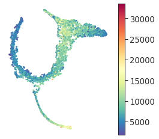

```python
fig, ax = palantir.plot.plot_tsne_by_cell_sizes(counts, tsne)
```

## MAGIC imputation

Palantirはデータの可視化と遺伝子発現トレンドの決定のため、MAGICを用いて Data imputation を行います。

```python
imp_df = palantir.utils.run_magic_imputation(norm_df, dm_res)
```

### 遺伝子発現量の可視化

Imputeされた発現量を用いた可視化

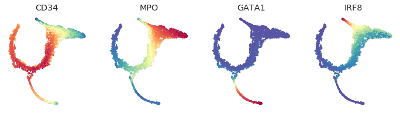

```python
palantir.plot.plot_gene_expression(imp_df, tsne, ['CD34', 'MPO', 'GATA1', 'IRF8'])
```

## Diffusion mapsの値の可視化

```
findfont: Font family ['Bitstream Vera Sans'] not found. Falling back to DejaVu Sans.
```

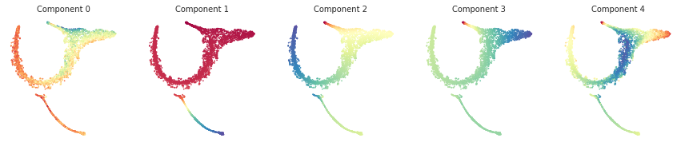

```python
palantir.plot.plot_diffusion_components(tsne, dm_res)
```

## Running Palantir

- Palantirは、early cellをおおよそ指定して実行します。
- Palantirはterminal statesを自動的に決定しますが、termine_statesパラメータを使って指定することもできます。
- このデータセットの開始セルは、CD34の高発現に基づいて選択されました。

```python
start_cell = 'Run5_164698952452459'
pr_res = palantir.core.run_palantir(ms_data, start_cell, num_waypoints=500)
```

```
Sampling and flocking waypoints...
Time for determining waypoints: 0.004217875003814697 minutes
Determining pseudotime...
Shortest path distances using 30-nearest neighbor graph...
Time for shortest paths: 2.401246798038483 minutes
Iteratively refining the pseudotime...
Correlation at iteration 1: 1.0000
Entropy and branch probabilities...
Markov chain construction...
Identification of terminal states...
Computing fundamental matrix and absorption probabilities...
Project results to all cells...
```

Palantir generates the following results

- Pseudotime: Pseudo time ordering of each cell
- Terminal state probabilities: Matrix of cells X terminal states. Each entry represents the probability of the corresponding cell reaching the respective terminal state
- Entropy: A quantiative measure of the differentiation potential of each cell computed as the entropy of the multinomial terminal state probabilities

The terminal states in this dataset are renamed to reflect the known biology below

```python
mapping = pd.Series(index=['DC', 'Mono', 'Ery'])
mapping['DC'] = tsne.loc[pr_res.branch_probs.columns, 'x'].idxmax()
mapping['Ery'] = tsne.loc[pr_res.branch_probs.columns, 'y'].idxmin()
mapping['Mono'] = pr_res.branch_probs.columns.difference(mapping.values)[0]
mapping = pd.Series(mapping.index, index=mapping)
```

```python
pr_res.branch_probs.columns = mapping[pr_res.branch_probs.columns]
pr_res.branch_probs = pr_res.branch_probs.loc[:, ['Ery', 'Mono', 'DC']]
```

## Visualizing Palantir results

Palantir results can be visualized on the tSNE map using the plot_palantir_results function

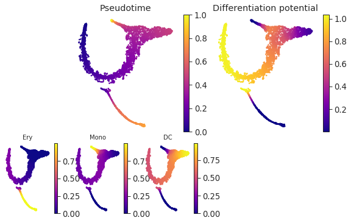

```python
palantir.plot.plot_palantir_results(pr_res, tsne)
```

### Terminal state probability distributions of individual cells

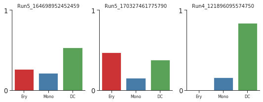

```python
cells = ['Run5_164698952452459', 'Run5_170327461775790', 'Run4_121896095574750', ]
palantir.plot.plot_terminal_state_probs(pr_res, cells)
```

[output not shown]

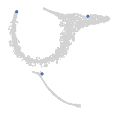

```python
# The cells can be highlighted on the tSNE map using the highlight_cells_on_tsne function
palantir.plot.highlight_cells_on_tsne(tsne, cells)
```

## Gene expression trends

- Palantirは Generalized Additive Models (GAMs)を使って、異なる系統に沿った遺伝子発現傾向を決定します。
- マーカーの傾向は、以下のコマンドで決定します。これは、すべての系統のトレンドを計算します。
- lineagesパラメータを使用して、系統のサブセットを使用することができます。

```python
genes = ['CD34', 'MPO', 'GATA1', 'IRF8']
gene_trends = palantir.presults.compute_gene_trends( pr_res, imp_df.loc[:, genes])
```

```
Ery
Time for processing Ery: 0.26758272647857667 minutes
Mono
Time for processing Mono: 0.10928091208140055 minutes
DC
Time for processing DC: 0.10784602562586466 minutes
```

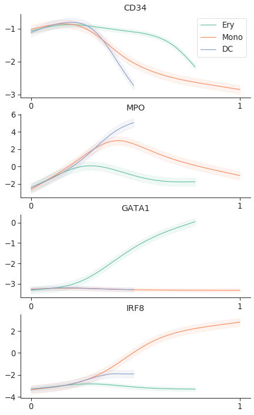

```python
palantir.plot.plot_gene_trends(gene_trends)
```

### Alternatively, the trends can be visualized on a heatmap using

```
findfont: Font family ['Bitstream Vera Sans'] not found. Falling back to DejaVu Sans.
```

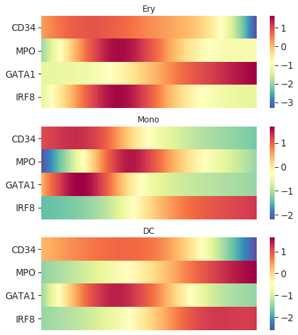

```python
palantir.plot.plot_gene_trend_heatmaps(gene_trends)
```

## Clustering

Cells can be clustered and visualized using **Phenograph**.

```python
clusters = palantir.utils.determine_cell_clusters(pca_projections)
```

```
Finding 50 nearest neighbors using minkowski metric and 'auto' algorithm
Neighbors computed in 3.2814152240753174 seconds
Jaccard graph constructed in 9.19353437423706 seconds
Wrote graph to binary file in 1.6953480243682861 seconds
Running Louvain modularity optimization
After 1 runs, maximum modularity is Q = 0.679434
After 2 runs, maximum modularity is Q = 0.680522
After 5 runs, maximum modularity is Q = 0.682021
Louvain completed 25 runs in 4.982285499572754 seconds
Sorting communities by size, please wait ...
PhenoGraph complete in 26.690869569778442 seconds
```

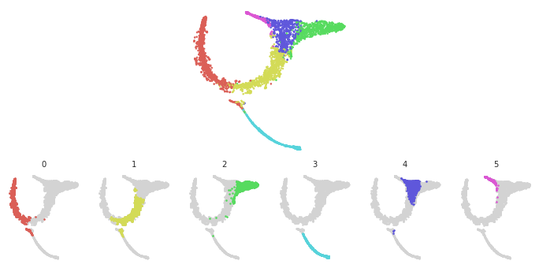

```python
palantir.plot.plot_cell_clusters(tsne, clusters )
```

同様に、遺伝子発現傾向もクラスタリングすることができる。 例として、赤血球に沿った最初の1000個の遺伝子をクラスター化します。

```python
gene_trends = palantir.presults.compute_gene_trends(pr_res,
                    imp_df.iloc[:, 0:1000], ['Ery'])
```

```
Ery
Time for processing Ery: 2.7329207181930544 minutes
```

```python
# Cluster
trends = gene_trends['Ery']['trends']
gene_clusters = palantir.presults.cluster_gene_trends(trends)
```

```
Finding 150 nearest neighbors using minkowski metric and 'auto' algorithm
Neighbors computed in 0.18087029457092285 seconds
Jaccard graph constructed in 12.861731767654419 seconds
Wrote graph to binary file in 1.0602805614471436 seconds
Running Louvain modularity optimization
After 1 runs, maximum modularity is Q = 0.596479
Louvain completed 21 runs in 2.4863691329956055 seconds
Sorting communities by size, please wait ...
PhenoGraph complete in 24.78569769859314 seconds
```

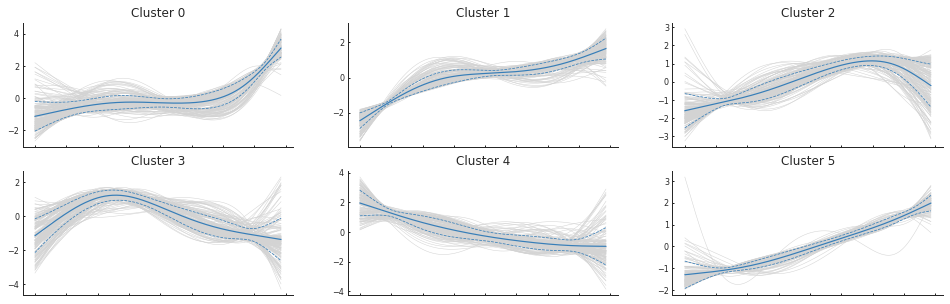

```python
palantir.plot.plot_gene_trend_clusters(trends, gene_clusters)
```